# Презентация к лабораторной работе 6

Выполнение

Власов Артем Сергеевич

1132246841@rudn.ru

Российский университет дружбы народов

# Информация

## Докладчик

- Власов Артем Сергеевич
- Студент
- Студент
- Российский университет дружбы народов им. П. Лумумбы
- 1132246841@rudn.ru
- https://vlasovas52.github.io/ru/

# Вводная часть

## Цели и задачи

Получить навыки управления процессами операционной систем. Продемонстрировать навыки умения работать с процессами и выполнить самостоятельное задание.

# Выполнение лабораторной работы 6

Получаем права администратора и запускаем процесс, ставим сремя неактива.

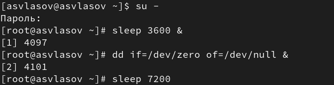

Запуск процесса

Смотрим информацию ог трех процессах которые мы только что запустили.

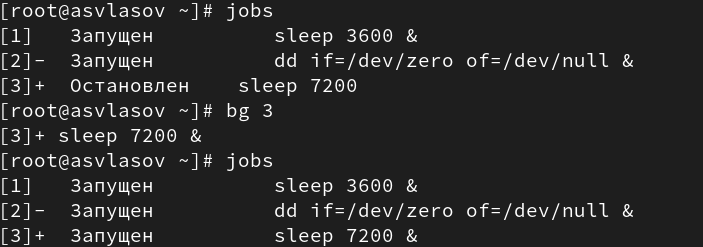

Список процессов

Продолжаем выполнение третьего процесса в фоновом режиме.

С помощью fg завершаем выполнение всех процессов по очереди.

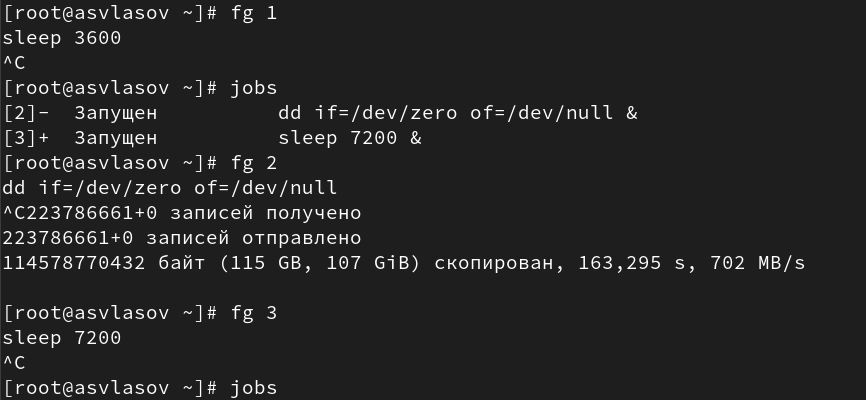

Завершаем процессы

В другом терминале запускаем новый процесс и выходим.

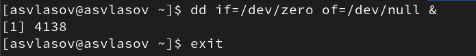

Другой терминал

С помощью top видим новый процесс и завершаем его.

Запускаем три процесса и ищем процессы с названием dd.

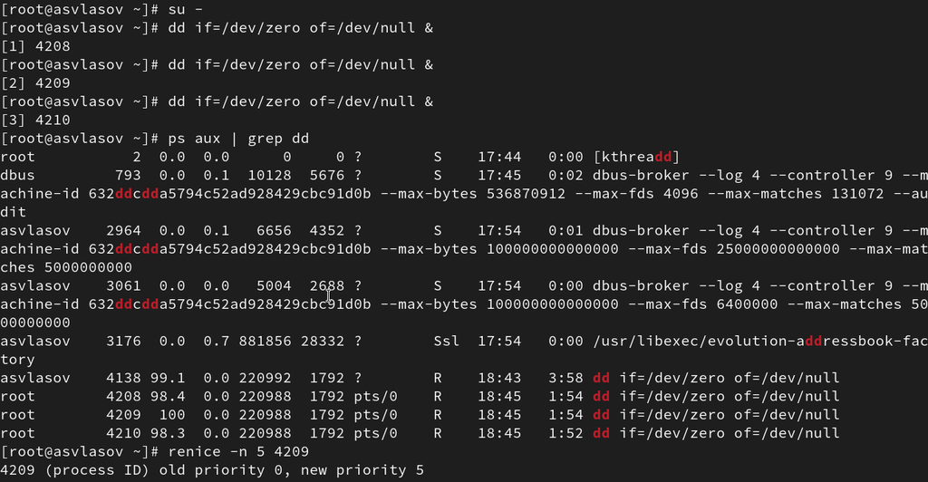

Поиск процессов

Заменяем приоритет процесса с помощью команды.

Смотрим иерархию процессов, и завершаем родительский процесс.

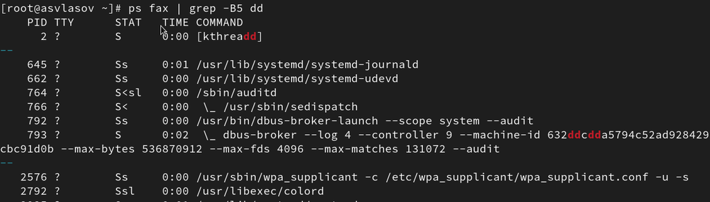

Иерархия процессов

Запускаем yes сначала в фоновом режиме, затем в лицевом, с помощью fg убиваем лицевой процесс.

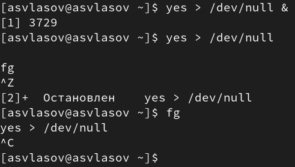

YES

Запускаем yes на переднем плане без подавления потока вывода.Завершаем процесс yes.

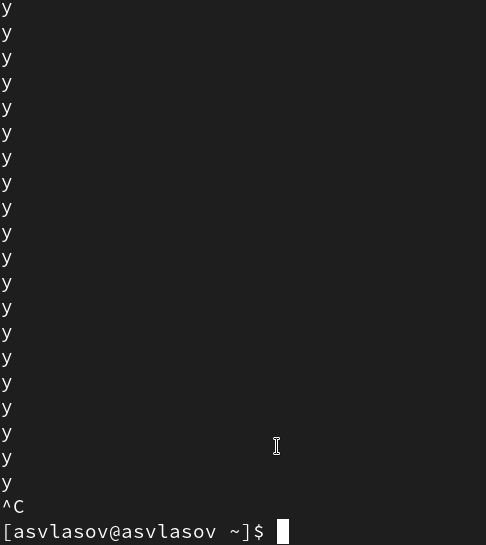

без подавления потока

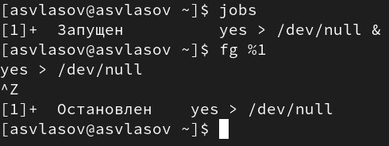

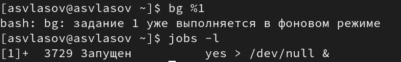

Фоновый режим

Запускаем процесс через nohup.Ищем все запущенные процессы yes.

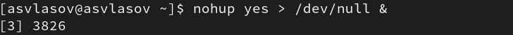

nohup

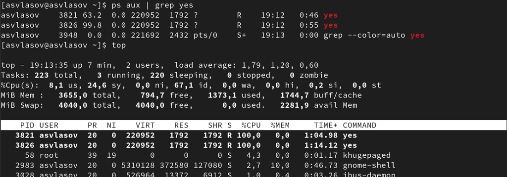

Запущенные процессы

Запускаем еще 3 процесса yes. Два из них сразу завершаем разными способами. Затем завершаем сразу все процессы yes.

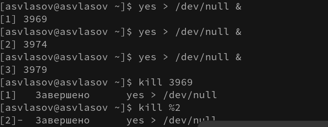

Запуск и завершение yes

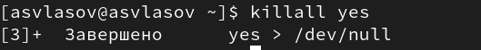

Завершение всех процессов

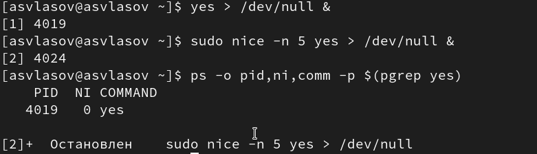

Сравнение параметров

Меняем приоритет процесса через renice.

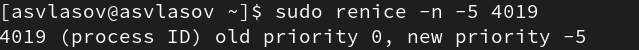

renice

# Выводы

Мы научились работать с процессами операционной системы и выполнили задания.